# Friday

### Question 28: Differences between groups. ANOSIM, adonis and SIMPER

ANOSIM gives you the P value and an R value. R value close to 1 indicates high separation between levels of your factor while R value close to 0 indicate no separation between levels of your factor.

Try also the recommended alternative “adonis” - Analysis of variance using distance matrices - for partitioning distance matrices among sources of variation and fitting linear models (e.g., factors, polynomial regression) to distance matrices; uses a permutation test with pseudo-F ratios.

#### Questions:

#### 28.1 What do the results from anosim and adonis tell you?

#### 28.2 Give one other example of predefined groups that could be used as the grouping variable(s)!

```r
# Start with a CA with Management as environmental factor and hulls around the different management types
dune.ca <- cca(dune)
fit.mgm <- envfit(dune.ca ~ Management, dune.env.original, perm = 0)
plot(dune.ca, type = "n", scaling = "symmetric")
with(
  dune.env.original,
  points(
    dune.ca,
    display = "sites",
    scaling = "symmetric",
    col = as.numeric(Management),
    pch = 16
  )
)
```

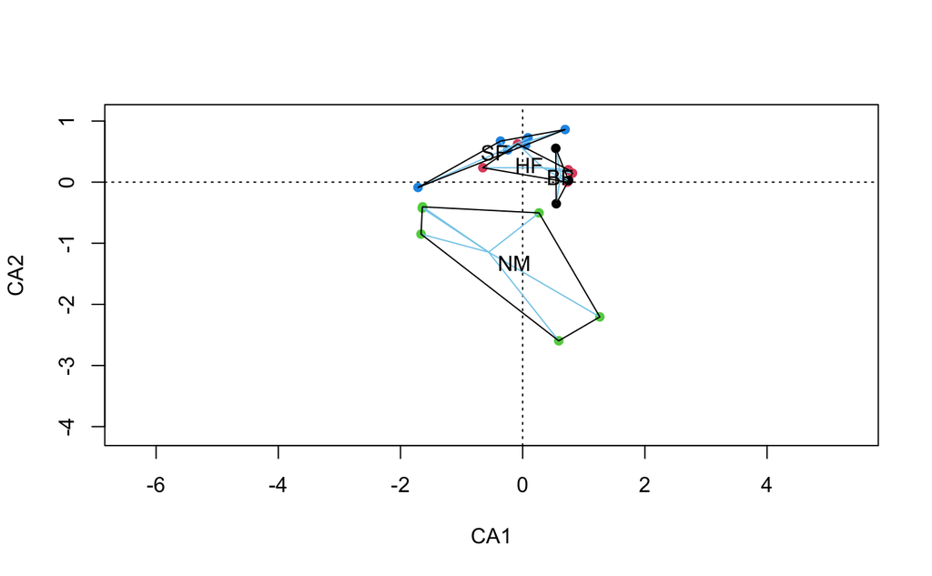

```r
with(
  dune.env.original,
  ordispider(dune.ca, Management, scaling = "symmetric", col = "skyblue")
)
with(dune.env.original,
     ordihull(dune.ca, Management, scaling = "symmetric", label = TRUE))
```

```r
dune.dist <-
  vegdist(dune, method = "bray") #create distance matrix based on Bray-Curtis method
dune.ano <-
  anosim(dune.dist, dune.env.original$Management) #Comparing groupings based on management
summary(dune.ano)
```

```
Call:
anosim(x = dune.dist, grouping = dune.env.original$Management)
Dissimilarity: bray

ANOSIM statistic R: 0.2579
      Significance: 0.016

Permutation: free
Number of permutations: 999

Upper quantiles of permutations (null model):
  90%   95% 97.5%   99%
0.113 0.165 0.225 0.264

Dissimilarity ranks between and within classes:
        0%   25%    50%     75%  100%   N
Between  4 58.50 104.00 145.500 188.0 147
BF       5 15.25  25.50  41.250  57.0   3
HF       1  7.25  46.25  68.125  89.5  10
NM       6 64.75 124.50 156.250 181.0  15
SF       3 32.75  53.50  99.250 184.0  15
```

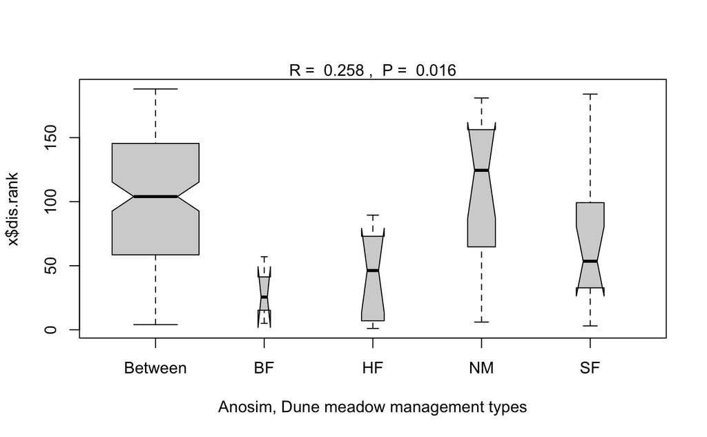

```r
plot(dune.ano, xlab = "Anosim, Dune meadow management types") #note the error message here:
```

[output not shown]

```r
#notches are used in box plots to help visually assess whether the medians of distributions #differ. If the notches do not overlap, this is evidence that the medians are different.Here #the confidence region (the notch) went past the bounds (or hinges) of one of the boxes.

#ANOSIM gives you the P value and a R value. R value close to 1 indicates high separation between levels of your factor while R value #close to 0 indicate no separation between levels of your factor.

# Try also the recommended alternative "adonis" - Analysis of variance using distance matrices - for partitioning distance matrices among sources of variation and fitting linear models (e.g., factors, polynomial regression) to distance matrices; uses a permutation test with pseudo-F ratios.

dune.ado<-adonis2(formula = dune~Management, data = dune.env.original, method = "bray")
dune.ado
```

```
Permutation test for adonis under reduced model
Terms added sequentially (first to last)
Permutation: free
Number of permutations: 999

adonis2(formula = dune ~ Management, data = dune.env.original, method = "bray")
           Df SumOfSqs      R2      F Pr(>F)
Management  3   1.4686 0.34161 2.7672  0.002 **
Residual   16   2.8304 0.65839
Total      19   4.2990 1.00000
---
Signif. codes:  0 ‘***’ 0.001 ‘**’ 0.01 ‘*’ 0.05 ‘.’ 0.1 ‘ ’ 1
```

```r
# You can also have more advanced models in adonis
dune.ado2<-adonis2(dune~Management*A1, data = dune.env.original)
dune.ado2
```

```
Permutation test for adonis under reduced model
Terms added sequentially (first to last)
Permutation: free
Number of permutations: 999

adonis2(formula = dune ~ Management * A1, data = dune.env.original)
              Df SumOfSqs      R2      F Pr(>F)
Management     3   1.4686 0.34161 3.2629  0.003 **
A1             1   0.4409 0.10256 2.9387  0.023 *
Management:A1  3   0.5892 0.13705 1.3090  0.216
Residual      12   1.8004 0.41878
Total         19   4.2990 1.00000
---
Signif. codes:  0 ‘***’ 0.001 ‘**’ 0.01 ‘*’ 0.05 ‘.’ 0.1 ‘ ’ 1
```

#### 28.3 Compare the different groups and check which species contribute mostly to the difference between pairs of clusters.

```r
sim <- simper(dune, dune.env.original$Management) #try management groupings
summary(sim)
```

```
Contrast: SF_BF

         average      sd   ratio     ava     avb cumsum     p
Agrostol 0.06137 0.03419 1.79490 4.66700 0.00000  0.098 0.050 *
Alopgeni 0.05267 0.03648 1.44390 4.33300 0.66700  0.182 0.116
Lolipere 0.04812 0.03945 1.21980 3.00000 6.00000  0.260 0.444
Trifrepe 0.04630 0.02553 1.81380 1.33300 4.66700  0.334 0.075 .
Poatriv  0.04602 0.03380 1.36150 4.66700 3.66700  0.407 0.557
Scorautu 0.04370 0.02492 1.75340 1.33300 4.33300  0.477 0.026 *
Bromhord 0.03368 0.02586 1.30230 0.50000 2.66700  0.531 0.017 *
Achimill 0.03015 0.02082 1.44820 0.16700 2.33300  0.580 0.018 *
Planlanc 0.02859 0.02155 1.32650 0.00000 2.00000  0.625 0.501
Elymrepe 0.02807 0.02978 0.94280 2.00000 1.33300  0.670 0.534
Bracruta 0.02550 0.02390 1.06690 2.00000 2.00000  0.711 0.832
Poaprat  0.02513 0.02397 1.04850 2.50000 4.00000  0.751 0.894
Sagiproc 0.02433 0.02215 1.09830 1.83300 0.66700  0.790 0.371
Bellpere 0.01986 0.01709 1.16220 0.66700 1.66700  0.822 0.101
Eleopalu 0.01861 0.04296 0.43330 1.33300 0.00000  0.852 0.847
Anthodor 0.01754 0.02580 0.67980 0.00000 1.33300  0.880 0.792
Juncbufo 0.01603 0.02371 0.67620 1.16700 0.00000  0.905 0.537
Vicilath 0.01467 0.01331 1.10260 0.00000 1.00000  0.929 0.020 *
Hyporadi 0.01029 0.01520 0.67680 0.00000 0.66700  0.945 0.618
Ranuflam 0.00931 0.01360 0.68450 0.66700 0.00000  0.960 0.908
Juncarti 0.00698 0.01611 0.43330 0.50000 0.00000  0.972 0.964
Callcusp 0.00698 0.01611 0.43330 0.50000 0.00000  0.983 0.833
Rumeacet 0.00453 0.01044 0.43330 0.33300 0.00000  0.990 0.960
Cirsarve 0.00398 0.00918 0.43360 0.33300 0.00000  0.996 0.384
Chenalbu 0.00233 0.00537 0.43330 0.16700 0.00000  1.000 0.402
Airaprae 0.00000 0.00000     NaN 0.00000 0.00000  1.000 0.720
Comapalu 0.00000 0.00000     NaN 0.00000 0.00000  1.000 0.731
Empenigr 0.00000 0.00000     NaN 0.00000 0.00000  1.000 0.448
Salirepe 0.00000 0.00000     NaN 0.00000 0.00000  1.000 0.846
Trifprat 0.00000 0.00000     NaN 0.00000 0.00000  1.000 0.867
---
Signif. codes:  0 ‘***’ 0.001 ‘**’ 0.01 ‘*’ 0.05 ‘.’ 0.1 ‘ ’ 1

Contrast: SF_HF

         average      sd   ratio     ava     avb cumsum     p
Agrostol 0.04738 0.03127 1.51510 4.66700 1.40000  0.084 0.263
```

[output cut: 162 more lines]

```
Callcusp 0.01683 0.02490 0.67600 0.00000 1.16700  0.886 0.444
Achimill 0.01656 0.01490 1.11100 1.20000 0.33300  0.909 0.631
Sagiproc 0.01528 0.01653 0.92400 0.80000 0.50000  0.930 0.879
Airaprae 0.01261 0.01824 0.69100 0.00000 0.83300  0.947 0.282
Bromhord 0.01209 0.01517 0.79700 0.80000 0.00000  0.964 0.838
Comapalu 0.01011 0.01456 0.69400 0.00000 0.66700  0.978 0.251
Bellpere 0.00880 0.01373 0.64100 0.40000 0.33300  0.990 0.932
Empenigr 0.00454 0.01033 0.43900 0.00000 0.33300  0.997 0.535
Vicilath 0.00240 0.00546 0.43900 0.00000 0.16700  1.000 0.867
Chenalbu 0.00000 0.00000     NaN 0.00000 0.00000  1.000 0.539
Cirsarve 0.00000 0.00000     NaN 0.00000 0.00000  1.000 0.548
---
Signif. codes:  0 ‘***’ 0.001 ‘**’ 0.01 ‘*’ 0.05 ‘.’ 0.1 ‘ ’ 1
Permutation: free
Number of permutations: 999
```

Visually compare the result from simper with species positions in a biplot.

```r
plot(dune.ca, type = "n", scaling = "species")
with(dune.env.original, points(dune.ca, display = "sites", scaling = "species", col = as.numeric(Management), pch=16))
```

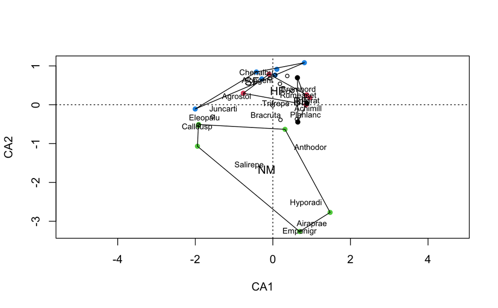

```r
with(dune.env.original, orditorp(dune.ca, display = "species", scaling = "species"))
with(dune.env.original, ordihull(dune.ca, Management, scaling = "species",label = TRUE))
```

A complementary/alternative approach to identifying which species are most reposnisble for the differences between the groups is that of indicator species - which species best characterise the groups or clusters that we have identified?

In this exercise we will investigate if any particular species are indicative for the four different management types.

#### 28.4 Use the resulting data table to find the two top indicator species for each of the four Management types!

```r
iva <- indval(dune, dune.env.original$Management) #this time we don't need dummy variables for management
iva.df <- as.data.frame(iva$indval)
#arrange in descending order to find best indicator species, change BF to other management types as needed
dplyr::arrange(rownames_to_column(iva.df), desc(HF))
```

| rowname | BF | HF | NM | SF |
| --- | --- | --- | --- | --- |
| Rumeacet | 0.00000000 | 0.72452830 | 0.000000000 | 0.015723270 |
| Trifprat | 0.00000000 | 0.60000000 | 0.000000000 | 0.000000000 |
| Poatriv | 0.18612521 | 0.36548223 | 0.000000000 | 0.355329949 |
| Poaprat | 0.37854890 | 0.32176656 | 0.021030494 | 0.157728707 |
| Planlanc | 0.22857143 | 0.30857143 | 0.047619048 | 0.000000000 |
| Lolipere | 0.45000000 | 0.30000000 | 0.004166667 | 0.112500000 |
| Bracruta | 0.13840830 | 0.29065744 | 0.196078431 | 0.138408304 |
| Trifrepe | 0.43887147 | 0.26332288 | 0.114942529 | 0.083594566 |
| Anthodor | 0.09950249 | 0.24179104 | 0.099502488 | 0.000000000 |
| Scorautu | 0.37249284 | 0.24068768 | 0.272206304 | 0.076408787 |

[output cut: 20 more lines]

### Question 29: DFA

The algorithm starts by finding directions that maximize the separation between classes, then use these directions to predict the class of individuals. These directions, called linear discriminants, are linear combinations of predictor variables. The Dune dataset is too small to really make use of this method (since we need to split the data into test and training parts) so we will here use the classic “Iris” dataset of different Iris plant species and the dimensions of different parts of their flowers

#### Questions:

#### 29.1 How well does the algorithm distinguish between the species?

#### 29.2 Here our groups are pre-defined (species). Would it be OK to use one of the clustering methods to find groups before running the DFA?

```r
# Load the data
data("iris")

# Split the data into training (80%) and test set (20%)
set.seed(123)
training.samples <- iris$Species %>%
  createDataPartition(p = 0.8, list = FALSE)
train.data <- iris[training.samples,]
test.data <- iris[-training.samples,]

# Discriminant analysis can be affected by the scale/unit in which predictor variables are measured.
# It’s generally recommended to standardize/normalize continuous predictor before the analysis.
# Normalize the data. Categorical variables are automatically ignored.
# Estimate preprocessing parameters
preproc.param <- train.data %>%
  preProcess(method = c("center", "scale"))
# Transform the data using the estimated parameters
train.transformed <- preproc.param %>% predict(train.data)
test.transformed <- preproc.param %>% predict(test.data)

# Linear discriminant analysis - LDA ####
# Fit the model
model <- lda(Species ~ ., data = train.transformed)

model
```

```
Call:
lda(Species ~ ., data = train.transformed)

Prior probabilities of groups:
    setosa versicolor  virginica
 0.3333333  0.3333333  0.3333333

Group means:
           Sepal.Length Sepal.Width Petal.Length Petal.Width
setosa       -1.0112835  0.78048647   -1.2900001  -1.2453195
versicolor    0.1014181 -0.68674658    0.2566029   0.1472614
virginica     0.9098654 -0.09373989    1.0333972   1.0980581

Coefficients of linear discriminants:
                    LD1         LD2
Sepal.Length  0.6794973  0.04463786
Sepal.Width   0.6565085 -1.00330120
Petal.Length -3.8365047  1.44176147
Petal.Width  -2.2722313 -1.96516251

Proportion of trace:
   LD1    LD2
0.9902 0.0098
```

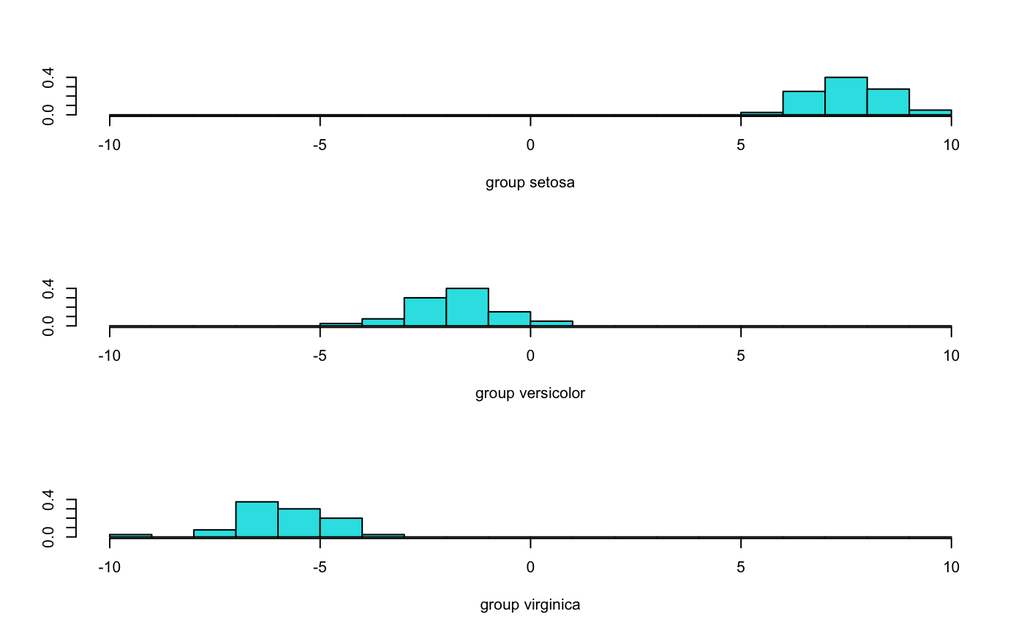

```r
plot(model, dimen = 1)#, type="both")
```

LDA determines group means and computes, for each individual, the probability of belonging to the different groups. Each observation/individual is then assigned to the group with the highest probability score.

The lda() outputs contain the following elements:

Prior probabilities of groups: the proportion of training observations in each group. For example 33% of the training observations are in the Setosa group.

Group means: group center of gravity. Shows the mean of each variable in each group.

Coefficients of linear discriminants: Shows the linear combination of predictor variables that are used to form the LDA decision rule. If the predictor variables are standardized before computing LDA, the discriminator weights can be used as measures of variable importance for feature selection.

Using the function plot() produces plots of the linear discriminants, obtained by computing LD1 and LD2 for each of the training observations.

```r
# Make predictions
predictions <- model %>% predict(test.transformed)
# Model accuracy
mean(predictions$class==test.transformed$Species)
```

```
[1] 0.9666667
```

```r
# The predict() function returns the following elements:
#
# class: predicted classes of observations.
# posterior: is a matrix whose columns are the groups, rows are the individuals and values are the posterior probability that the corresponding observation belongs to the groups.
# x: contains the linear discriminants, described above

# Predicted classes
head(predictions$class, 6)
```

```
[1] setosa setosa setosa setosa setosa setosa
Levels: setosa versicolor virginica
```

```r
# Predicted probabilities of class membership.
head(predictions$posterior, 6)
```

```
   setosa   versicolor    virginica
1       1 3.978425e-22 1.319337e-43
2       1 1.038098e-17 3.967605e-38
6       1 2.882148e-21 2.041612e-41
16      1 8.381782e-28 7.486309e-50
23      1 6.531615e-25 3.414098e-47
34      1 1.089899e-28 7.865614e-52
```

```r
# Linear discriminants
head(predictions$x, 3)
```

```
       LD1        LD2
1 8.162939 -0.5052768
2 7.202713  0.7111062
6 7.816243 -1.7327151
```

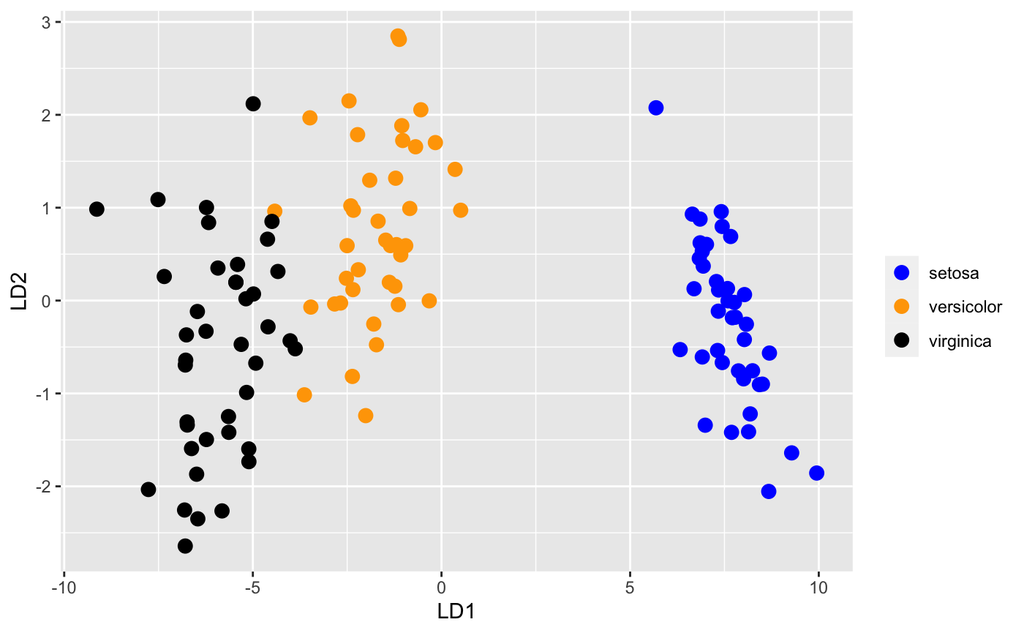

```r
lda.data <- cbind(train.transformed, predict(model)$x)
#lda.data <- cbind(test.transformed, predictions$x)
ggplot(lda.data, aes(LD1, LD2)) +
  geom_point(aes(color = Species),size=3)+
  scale_colour_manual(name="",
                      values = c("setosa"="blue", "versicolor"="orange", "virginica"="black"))
```

```r
# Model accuracy
mean(predictions$class==test.transformed$Species)
```

```
[1] 0.9666667
```

```r
#More detailed assessment (probably more information than we need!)
#Calculates a cross-tabulation of observed and predicted classes with associated statistics.
confusionMatrix(test.data$Species, predictions$class)
```

```
Confusion Matrix and Statistics

            Reference
Prediction   setosa versicolor virginica
  setosa         10          0         0
  versicolor      0         10         0
  virginica       0          1         9

Overall Statistics

               Accuracy : 0.9667
                 95% CI : (0.8278, 0.9992)
    No Information Rate : 0.3667
    P-Value [Acc > NIR] : 4.476e-12

                  Kappa : 0.95

 Mcnemar's Test P-Value : NA

Statistics by Class:

                     Class: setosa Class: versicolor Class: virginica
Sensitivity                 1.0000            0.9091           1.0000
Specificity                 1.0000            1.0000           0.9524
Pos Pred Value              1.0000            1.0000           0.9000
Neg Pred Value              1.0000            0.9500           1.0000
Prevalence                  0.3333            0.3667           0.3000
Detection Rate              0.3333            0.3333           0.3000
Detection Prevalence        0.3333            0.3333           0.3333
Balanced Accuracy           1.0000            0.9545           0.9762
```

### Question 30: Model based ordination

Dissimilarity-based ordination methods begin by calculating a dissimilarity or distance matrix between sites (or more generally, observational units). Afterwards, these are collapsed to a small number of dimensions for plotting using an algorithm that attempts to preserve and display information about these relative distances. The model-based approach explicitly specifies a statistical model of the process that generated the observed data. Model-based ordination methods (mostly) use an extension of generalised linear mixed models known as latent variable models. As the name suggests, these models account for the correlation between taxa via the inclusion of a small number of latent variables. Latent variables act as natural ordination axes reflecting unobserved covariates.

#### Question:

#### 30.1 How do the ordinations produced compare to a distance based ordination (for example an NMDS) of the same species data?

```r
#load species abundance data
spe<-as.data.frame(read_xlsx("dune.xlsx", na = ".",sheet = 1, col_names = TRUE)); spe[1]<-NULL
#we need to provide the model with an appropriate probability distribution for the data.
#Given our abundance data is on a scale of 1 - 9 we could classify it as ordinal data,
#but we can try another distribution as well to compare results.

fitnb <- gllvm(y = spe, family = "negative.binomial") #This takes a minute or so to run!
fitord <- gllvm(y = spe, family = "ordinal", zeta.struc = "common")
#ignore the warning messages generated for now!

#As with "normal" linear regressions we can check model fit with widely used tools like
#Akaike Information Criterion (AIC). AIC aims to select the model which best explains
#the variance in the dependent variable with the fewest number of independent variables
#So it helps select a simpler model over a complex model, if the complexity is not helpful.
#A lower AIC is better!

AIC(fitnb)
```

```
[1] 1411.257
```

```r
AIC(fitord)
```

```
[1] 1169.32
```

```r
#It seems the ordinal model is the best.
```

We can also use graphical checks of model fit, as with any regression. If you are familiar with these try running plot(fitord) and plot(fitnb).

Now we can look at the ordination plot for the best model.

```r
par(mfrow = c(1, 2))
ordiplot.gllvm(
  fitord,
  main = NULL,
  biplot = T,
  s.colors = "black",
  spp.colors = "blue",
  alpha = 0.45,
  cex.spp = 0.7,
  jitter = F,
  s.cex = 0.6
)

abline(h = 0, v = 0, lty = 2)
```

```r
#compare with an NMDS
distord <- metaMDS(spe)
```

```
*** Best solution repeated 7 times
```

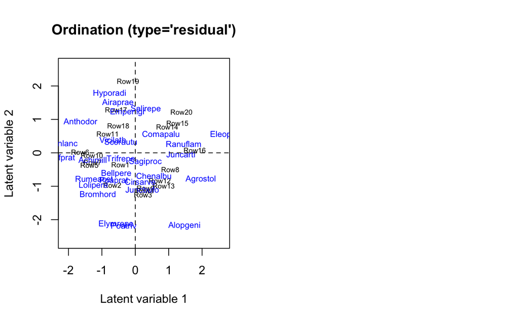

```r
vegan::ordiplot(distord, type = "t")
par(mfrow = c(1, 1))
```

[output not shown]

We can do a lot more with model based ordinations, including incorporating environmental variables. We can also include information on traits and perform a fourth corner analysis.

### Question 31: Fourth Corner

Here we will use another model based method (the “mvabund” package for analysing multivariate abundance data) to perform a fourth corner analysis. That is to say we will include trait information and environmental variables, and investigate the relationship between plant traits and environmental variables.

#### Question:

#### 31.1 Do the correlations in the plot make sense ecologically?

```r
# Read and treat data

env<-as.data.frame(read_xlsx("dune_env.xlsx", na = "NA",sheet = 1, col_names = TRUE)); env[1]<-NULL
env$Management<-as.factor(env$Management)
env$Use<-as.factor(env$Use)
#This is from a database of plant traits
traits<-as.data.frame(read_xlsx("TylerTraits.xlsx", na = "NA",sheet = 1, col_names = TRUE, skip = 1))
rownames(traits)<-traits$Spe; traits$Spe<-NULL
names(traits)
```

```
 [1] "LightEll"  "TempEll"   "ContEll"   "MoistEll"  "ReactEll"  "NutrEll"   "BioDivRel" "Nectar"    "Heat"      "Cold"
[11] "TempTY"    "ContTY"    "LightTY"   "MoistTY"   "pH"        "N"         "P"         "NaCl"      "Gazing"    "SoilDist"
[21] "Long"      "PollinDep" "Phen"      "ExtrPhen"  "SeedDorm"  "SeeBank"   "SeedDisp"  "N_fix"     "PhotoSyn"  "Mycorr"
[31] "Carinv"    "Parasit"
```

```r
traits<-traits[,-c(1:6,22, 27,29,30:32)] # Remove trait not feasible for this analysis

#Fourth corner
#Given that there are many traits and even environmental factors that are not strong predictors #of abundance, we can reduce the number of predictor terms in our models.LASSO is an #optimization algorithm (Least Absolute Shrinkage and Selection Operator) that is used in this #case.

fitfourth = traitglm(spe, env, traits, method = "glm1path")
fitfourth$fourth #examine fourth corner terms
```

```
                    A1    Moisture  ManagementBF ManagementHF ManagementNM ManagementSF UseHayfield  UseHaypastu   UsePasture
BioDivRel  0.000000000 -0.24187112  0.0000000000  0.184593640  -0.04357440  0.000000000  0.00000000  0.000000000 -0.049770100
Nectar     0.000000000  0.02150832  0.0000000000 -0.022140593   0.20036167  0.000000000  0.00000000  0.000000000  0.000000000
Heat       0.000000000  0.00000000  0.0000000000 -0.034145942   0.07678202  0.000000000  0.00000000 -0.087928761  0.000000000
Cold       0.000000000  0.00000000  0.0000000000 -0.051223034   0.01941461  0.000000000  0.00000000  0.000000000  0.000000000
TempTY     0.000000000  0.00000000  0.0000000000  0.000000000   0.00000000  0.000000000  0.00000000  0.004915853  0.000000000
ContTY     0.000000000  0.00000000  0.0000000000  0.000000000  -0.09570865  0.000000000  0.00000000  0.000000000 -0.002706887
LightTY5   0.000000000  0.00000000  0.0000000000  0.000000000   0.00000000  0.000000000  0.00000000  0.000000000  0.000000000
LightTY6   0.000000000  0.00000000  0.0000000000  0.000000000   0.00000000  0.000000000  0.00000000  0.000000000  0.043440244
LightTY7   0.000000000  0.00000000  0.0000000000  0.000000000   0.00000000  0.000000000  0.00000000  0.000000000 -0.061019951
MoistTY    0.157735518  0.47839257 -0.0140514310  0.000000000   0.00000000  0.000000000 -0.02636700  0.000000000  0.000000000
pH         0.000000000 -0.16110799  0.1203535140  0.000000000   0.00000000  0.000000000  0.00000000  0.000000000  0.000000000
N          0.000000000  0.00000000  0.0645435913  0.000000000   0.00000000  0.010826422  0.00000000  0.047141784 -0.020923118
P          0.000000000  0.04099960  0.0000000000 -0.005049321   0.00000000  0.030180567  0.00000000  0.000000000  0.000000000
NaCl1     -0.027365012 -0.07925440  0.0309898396  0.000000000   0.00000000  0.000000000  0.00000000  0.000000000  0.000000000
NaCl2      0.000000000  0.00000000  0.0000000000  0.005390422   0.00000000  0.000000000  0.03336487  0.000000000  0.000000000
NaCl3      0.003862888  0.07970341 -0.1431739477 -0.074115504   0.00000000  0.025066741  0.00000000  0.000000000  0.000000000
Gazing     0.000000000  0.00000000  0.0426933815  0.000000000   0.00000000  0.000000000  0.00000000  0.000000000  0.000000000
SoilDist   0.000000000  0.21600562  0.0000000000  0.000000000   0.00000000  0.000000000  0.00000000  0.000000000  0.000000000
Long1      0.000000000  0.00000000  0.0001292358  0.000000000   0.00000000  0.000000000  0.00000000  0.000000000  0.000000000
Long3      0.000000000  0.00000000  0.0000000000  0.000000000  -0.10823075  0.012058878  0.00000000  0.035112779  0.000000000
Long4      0.000000000  0.00000000  0.0000000000  0.000000000   0.05163007 -0.037679131  0.00000000 -0.011827518  0.000000000
Phen       0.000000000  0.05963801  0.0000000000  0.000000000   0.00000000  0.000000000 -0.04086785  0.000000000  0.015767718
ExtrPhen   0.000000000  0.00000000 -0.0316969682  0.000000000   0.09032946  0.000000000  0.00000000 -0.004323280  0.000000000
SeedDorm   0.000000000  0.00000000  0.0000000000  0.000000000   0.00000000  0.000000000  0.01192357  0.000000000  0.000000000
SeeBank    0.000000000  0.00000000 -0.0404989047  0.000000000  -0.14512123  0.005301894 -0.04460693  0.000000000  0.000000000
N_fix1     0.091846380  0.00000000  0.0000000000  0.000000000   0.00000000  0.000000000 -0.05249002  0.000000000  0.024599950
                Manure
BioDivRel  0.000000000
Nectar    -0.133625089
Heat       0.000000000
Cold       0.000000000
TempTY     0.000000000
ContTY     0.000000000
LightTY5  -0.001832491
LightTY6   0.000000000
LightTY7   0.000000000
MoistTY    0.000000000
pH         0.145034963
N          0.290348917
P          0.000000000
NaCl1      0.000000000
NaCl2     -0.015999727
NaCl3      0.000000000
Gazing     0.000000000
SoilDist   0.000000000
Long1      0.000000000
Long3      0.000000000
Long4      0.000000000
Phen       0.000000000
ExtrPhen   0.000000000
SeedDorm   0.000000000
SeeBank    0.000000000
N_fix1     0.000000000
```

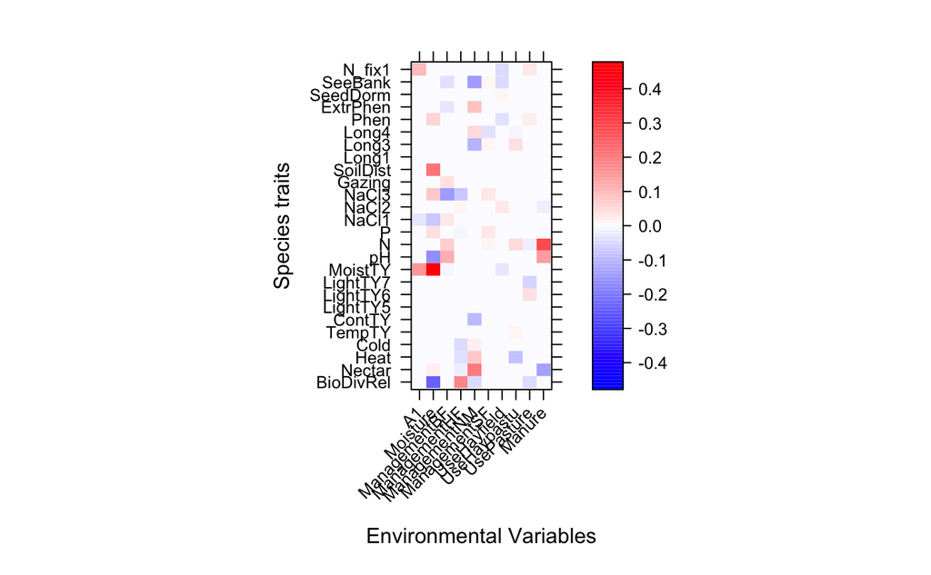

```r
#and plot the results
a        = max(abs(fitfourth$fourth.corner))
colort   = colorRampPalette(c("blue", "white", "red"))
plot.4th = levelplot(
  t(as.matrix(fitfourth$fourth.corner)),
  xlab = "Environmental Variables",
  ylab = "Species traits",
  col.regions = colort(100),
  at = seq(-a, a, length = 100),
  scales = list(x = list(rot = 45))
)
print(plot.4th)
```

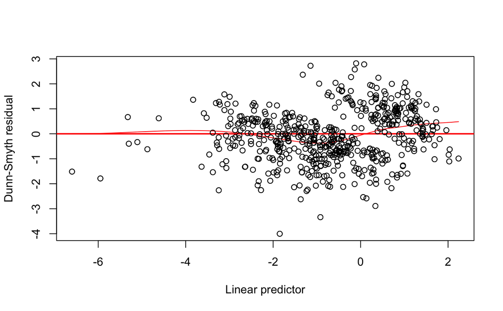

```r
plot(fitfourth) # for a Dunn-smyth residual plot
```

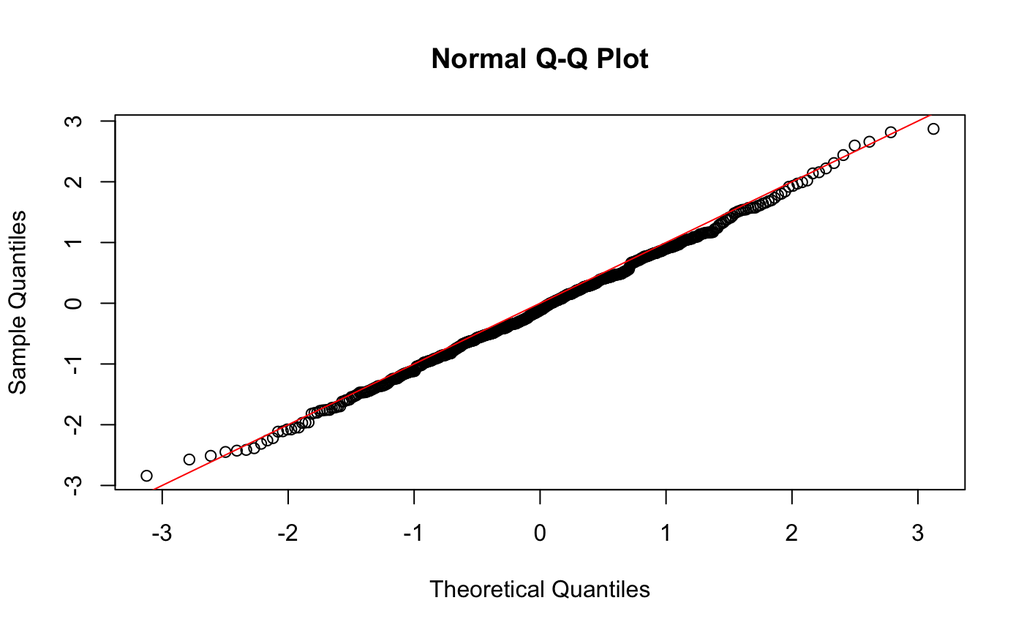

```r
qqnorm(residuals(fitfourth)); abline(c(0,1),col="red") # for a normal quantile plot.
```

```r
#We can test for overall significance using an anova (only on default manyglm model,
#not available for Lasso model)
fitfourth2 = traitglm(spe, env, traits)
pvalues <- anova.traitglm(fitfourth2,nBoot=10) #overall significant
```

[output not shown]

```
Using block resampling...
Resampling begins for test 1.
    Resampling run 0 finished. Time elapsed: 0.04 minutes...
Time elapsed: 0 hr 0 min 26 sec
```

```r
#We can also explore the effects of individual trait by environment interactions using the #summary function ** Warning this is very very #slow, even with limited n** Don't run this
#last line of code unless you want to take a long coffee break!
#We will limit the number of bootstrap reps to 5 (nBoot=5) but 1000 should be using for final analyses
#summary(fitfourth2, nboot=5)
#Example of output if you don't want to wait for the code to run...
#UsePasture.N_fix1           0.467     0.115
#Manure.BioDivRel            0.782     0.014 *
#Manure.Nectar               0.591     0.015 *
```